# Análisis de los Pitchers con mejor efectividad en la temporada 2022 de la MLB

Alvaro Goncalves & Yonelvis Gonzalez

#### (con el dataset de ” 2022 MLB Player Stats -Pitching”)

# *Planteamiento del problema*

Somos un grupo de aficionados que busca analizar a los pitchers con mayor efectividad de la temporada 2022 de la MLB. El rendimiento de los jugadores es la base del análisis sobre cualquier equipo y por lo tanto se desea observar la existencia de una relación entre el comportamiento y participación de un jugador con respecto a su edad.

## *Objetivos de investigación*

### *Objetivo Principal*

Analizar el comportamiento de los pitcher con mayor participación en la temporada 2022 de la MLB para evaluar la existencia de alguna relación con respecto a su efectividad. Utilizando las métricas ERA y WHIP para evaluar la efectividad de los jugadores y IP (Innings pitched).

### *Objetivos específicos*

#### 1-Determinar si existe una correlación estadísticamente significativa entre participación (medida en IP) y la edad de los pitchers con mayor participación (con un IP > 50) en la temporada 2022 de la MLB.

#### 2-Identificar y comparar las métricas de efectividad (ERA y WHIP) y edad del grupo de pitchers con mayor volumen de IP frente al promedio de la liga en 2022.

#### 3-Evaluar la relación entre la participación (IP) y la efectividad independiente en el “fildeo” (FIP) para garantizar un análisis completo del rendimiento individual de los pitchers con mayor participación.

#### 4-Evaluar la relación de efectividad (ERA) con la métrica de durabilidad/participación (IP) para identificar la eficiencia.

# ⚾️ Marco Teórico

## **I.Fundamentos:**

El análisis se basará en la distinción entre las métricas de rendimiento que incluyen la influencia defensiva y las que son independientes de ella.

### **A. Métricas de Efectividad:**

Estas métricas son las que nos permiten poder tener una noción de la efectividad de un jugador y las que se desean evaluar en relación con la participación y su edad.

**ERA (Earned Run Average):** Promedio de carreras limpias permitidas por cada nueve entradas lanzadas. (se utilizo en el objetivo 2, 4 y 5.1 para comparar el rendimiento y evaluar la eficiencia) **WHIP (Walks plus Hits per Innings Pitched):** Número promedio de hits y bases por bola permitidos por entrada lanzada. Mide el control y el dominio de corredores en base.(se utilizo para el objetivo 2 y 5 como métrica de control y para clasificar los mejores pitchers)

### **B. Métricas de participación y habilidad individual:**

Estas métricas sirven como variables independientes (participación/IP) y como herramientas de desambiguación de la efectividad (FIP).

**IP (Innings Pitched):** Entradas lanzadas. Es la métrica de carga de trabajo o durabilidad. (Es la variable central de participación para los Objetivos 1, 2, 3 y 4. Define el grupo de estudio (“mayor participación”).)

**FIP (Fielding Independent Pitching):** Mide la efectividad del pitcher basándose solo en los resultados que controla (ponches, bases por bola y jonrones), eliminando la influencia de la defensa. (Se utiliza para el Objetivo 3 para garantizar un análisis completo y separar la habilidad pura de la suerte/defensa.)

## **II. Enfoque Metodológico: Estadística Descriptiva y Relacional**

El estudio empleará un diseño descriptivo y correlacional para cumplir con los objetivos.

### **A. Determinación de Parámetros de Élite (Objetivo 2)**

**1.Criterio de Selección:** Definir al grupo de “mayor participación” seleccionando a los pitchers con IP > 50 para garantizar que sean abridores con una participación constante.

**2.Cálculo de Referencia:** Obtener las métricas ERA y WHIP Promedio de la MLB 2022 para establecer los puntos de referencia con los cuales se comparará el grupo élite.

### **B. Herramientas de Análisis de Relación (Objetivo 1, 4)**

**-Análisis de correlación** **-Gráficos de dispersión**

### **C. Análisis de Eficiencia y Desempeño Puro (Objetivo 3, 4)**

**Análisis FIP vs. ERA (Objetivo 3):** Se comparará el FIP con el ERA para cada pitcher de alta participación. Una diferencia grande entre FIP y ERA indicará un fuerte efecto de la defensa o la suerte.

¨**Eficiencia (Objetivo 4):** La eficiencia se evaluará observando si los pitchers con mayor durabilidad (IP) son también los más efectivos (ERA más bajo). Esto se puede visualizar en el gráfico ERA con respecto a IP.

### **D. Clasificación (Objetivos 5, 5.1)**

El estudio concluirá con una clasificación descriptiva del grupo de élite, utilizando las métricas de efectividad de ERA y WHIP para determinar quiénes fueron los más dominantes en el grupo de alta carga de trabajo.

# *Análisis de datos*

En este datatable podemos visualizar la información sin ningún filtro ni cambio realizado.

```r
summary(mlb_pitching)
```

```
##        Rk           Name                Age             Tm
##  Min.   :   1   Length:1081        Min.   :21.00   Length:1081
##  1st Qu.: 271   Class :character   1st Qu.:26.00   Class :character
##  Median : 541   Mode  :character   Median :28.00   Mode  :character
##  Mean   : 541                      Mean   :28.62
##  3rd Qu.: 811                      3rd Qu.:31.00
##  Max.   :1081                      Max.   :42.00
##       Lg                  W                L               W.L.
##  Length:1081        Min.   : 0.000   Min.   : 0.000   Min.   :0.0000
##  Class :character   1st Qu.: 0.000   1st Qu.: 0.000   1st Qu.:0.0000
##  Mode  :character   Median : 1.000   Median : 1.000   Median :0.3330
##                     Mean   : 2.446   Mean   : 2.477   Mean   :0.3454
##                     3rd Qu.: 4.000   3rd Qu.: 4.000   3rd Qu.:0.5710
##                     Max.   :21.000   Max.   :19.000   Max.   :1.0000
##       ERA              G               GS               GF
##  Min.   : 0.00   Min.   : 1.00   Min.   : 0.000   Min.   : 0.000
##  1st Qu.: 3.01   1st Qu.: 5.00   1st Qu.: 0.000   1st Qu.: 0.000
##  Median : 4.21   Median :17.00   Median : 0.000   Median : 2.000
##  Mean   : 5.39   Mean   :21.87   Mean   : 4.821   Mean   : 5.168
##  3rd Qu.: 6.04   3rd Qu.:32.00   3rd Qu.: 4.000   3rd Qu.: 7.000
##  Max.   :60.75   Max.   :77.00   Max.   :33.000   Max.   :67.000
##        CG               SHO                SV               IP
##  Min.   :0.00000   Min.   :0.00000   Min.   : 0.000   Min.   :  0.10
##  1st Qu.:0.00000   1st Qu.:0.00000   1st Qu.: 0.000   1st Qu.:  7.20
##  Median :0.00000   Median :0.00000   Median : 0.000   Median : 27.00
##  Mean   :0.03515   Mean   :0.01573   Mean   : 1.301   Mean   : 43.56
##  3rd Qu.:0.00000   3rd Qu.:0.00000   3rd Qu.: 0.000   3rd Qu.: 61.00
##  Max.   :6.00000   Max.   :1.00000   Max.   :42.000   Max.   :228.20
##        H               R                ER               HR
##  Min.   :  0.0   Min.   :  0.00   Min.   :  0.00   Min.   : 0.000
##  1st Qu.:  8.0   1st Qu.:  5.00   1st Qu.:  5.00   1st Qu.: 1.000
##  Median : 26.0   Median : 15.00   Median : 14.00   Median : 3.000
##  Mean   : 40.6   Mean   : 21.44   Mean   : 19.55   Mean   : 5.308
##  3rd Qu.: 53.0   3rd Qu.: 29.00   3rd Qu.: 26.00   3rd Qu.: 7.000
##  Max.   :210.0   Max.   :119.00   Max.   :107.00   Max.   :38.000
##        BB             IBB               SO              HBP
##  Min.   : 0.00   Min.   :0.0000   Min.   :  0.00   Min.   : 0.000
##  1st Qu.: 4.00   1st Qu.:0.0000   1st Qu.:  6.00   1st Qu.: 0.000
##  Median :11.00   Median :0.0000   Median : 26.00   Median : 1.000
##  Mean   :15.27   Mean   :0.5097   Mean   : 41.51   Mean   : 2.105
```

[output cut: 8 more lines]

```
##  Max.   :3.0000   Max.   :15.000   Max.   :886.0   Max.   :1227.00
##       FIP              WHIP              H9             HR9
##  Min.   :-2.890   Min.   : 0.000   Min.   : 0.00   Min.   : 0.00
##  1st Qu.: 3.280   1st Qu.: 1.141   1st Qu.: 7.10   1st Qu.: 0.50
##  Median : 4.220   Median : 1.343   Median : 8.50   Median : 1.00
##  Mean   : 5.033   Mean   : 1.518   Mean   : 9.56   Mean   : 1.45
##  3rd Qu.: 5.250   3rd Qu.: 1.612   3rd Qu.:10.50   3rd Qu.: 1.60
##  Max.   :51.110   Max.   :12.000   Max.   :81.00   Max.   :27.00
##       BB9              SO9              SO.W
##  Min.   : 0.000   Min.   : 0.000   Min.   : 0.000
##  1st Qu.: 2.300   1st Qu.: 6.300   1st Qu.: 1.330
##  Median : 3.400   Median : 8.100   Median : 2.160
##  Mean   : 4.107   Mean   : 7.866   Mean   : 2.419
##  3rd Qu.: 4.700   3rd Qu.: 9.700   3rd Qu.: 3.170
##  Max.   :81.000   Max.   :27.000   Max.   :34.000
```

```r
datatable(mlb_pitching,
          options = list(
    scrollX = TRUE,
    scrollY = "300px"
  ))
```

|  | Rk | Name | Age | Tm | Lg | W | L | W.L. | ERA | G | GS | GF | CG | SHO | SV | IP | H | R | ER | HR | BB | IBB | SO | HBP | BK | WP | BF | ERA. | FIP | … |
| --- | --- | --- | --- | --- | --- | --- | --- | --- | --- | --- | --- | --- | --- | --- | --- | --- | --- | --- | --- | --- | --- | --- | --- | --- | --- | --- | --- | --- | --- | --- |
| 1 | 1 | Cory Abbott | 26 | WSN | NL | 0 | 5 | 0 | 5.25 | 16 | 9 | 7 | 0 | 0 | 0 | 48 | 44 | 30 | 28 | 12 | 25 | 0 | 45 | 5 | 0 | 2 | 216 | 75 | 6.36 | … |
| 2 | 2 | Albert Abreu | 26 | TOT | AL | 2 | 2 | 0.5 | 3.26 | 33 | 0 | 11 | 0 | 0 | 0 | 38.2 | 35 | 15 | 14 | 5 | 22 | 0 | 38 | 3 | 0 | 6 | 172 | 123 | 4.77 | … |
| 3 | 3 | Albert Abreu | 26 | TEX | AL | 0 | 0 | 0 | 3.12 | 7 | 0 | 0 | 0 | 0 | 0 | 8.2 | 4 | 3 | 3 | 2 | 12 | 0 | 9 | 1 | 0 | 0 | 42 | 133 | 8.54 | … |
| 4 | 4 | Albert Abreu | 26 | KCR | AL | 0 | 0 | 0 | 4.15 | 4 | 0 | 3 | 0 | 0 | 0 | 4.1 | 6 | 2 | 2 | 1 | 4 | 0 | 3 | 1 | 0 | 1 | 22 | 106 | 8.19 | … |
| 5 | 5 | Albert Abreu | 26 | NYY | AL | 2 | 2 | 0.5 | 3.16 | 22 | 0 | 8 | 0 | 0 | 0 | 25.2 | 25 | 10 | 9 | 2 | 6 | 0 | 26 | 1 | 0 | 5 | 108 | 124 | 2.92 | … |
| 6 | 6 | Bryan Abreu | 25 | HOU | AL | 4 | 0 | 1 | 1.94 | 55 | 0 | 18 | 0 | 0 | 2 | 60.1 | 45 | 16 | 13 | 2 | 26 | 0 | 88 | 4 | 0 | 7 | 248 | 198 | 2.12 | … |
| 7 | 7 | Domingo Acevedo | 28 | OAK | AL | 4 | 4 | 0.5 | 3.33 | 70 | 0 | 12 | 0 | 0 | 4 | 67.2 | 50 | 26 | 25 | 9 | 17 | 4 | 58 | 3 | 1 | 1 | 266 | 113 | 4.01 | … |
| 8 | 8 | Jason Adam | 30 | TBR | AL | 2 | 3 | 0.4 | 1.56 | 67 | 0 | 16 | 0 | 0 | 8 | 63.1 | 31 | 12 | 11 | 5 | 17 | 2 | 75 | 6 | 0 | 2 | 237 | 238 | 2.86 | … |
| 9 | 9 | Austin Adams | 31 | SDP | NL | 1 | 0 | 1 | 0 | 2 | 0 | 0 | 0 | 0 | 0 | 2.1 | 0 | 0 | 0 | 0 | 3 | 0 | 2 | 0 | 0 | 0 | 9 | 0 | 5.25 | … |
| 10 | 10 | Joan Adon | 23 | WSN | NL | 1 | 12 | 0.077 | 7.1 | 14 | 14 | 0 | 0 | 0 | 0 | 64.2 | 76 | 53 | 51 | 8 | 39 | 1 | 55 | 6 | 0 | 7 | 310 | 55 | 5.11 | … |

[output cut: 1071 more lines]

```r
is.na <- 0
rango_ip <- 50
#establecemos un rango para dividir en grupos a los jugadores en este caso los que tengan mayor IP y menor ERA demostraran tener un muy buen rendimiento
mlb_players <- mlb_pitching %>% group_by(Name) %>%
  filter(n() == 1 | Tm == "TOT") %>% ungroup() %>% filter(!is.na(ERA)& is.finite(ERA) & IP >= rango_ip & !is.na(IP)) %>%
  select(
    Name,
    Age,
    IP,
    ERA,
    WHIP,
    FIP,
  ) %>% arrange(ERA)
datatable(mlb_players, options = list(
            scrolly = "300px"))
```

|  | Name | Age | IP | ERA | WHIP | FIP |
| --- | --- | --- | --- | --- | --- | --- |
| 1 | Evan Phillips | 27 | 63 | 1.14 | 0.762 | 1.94 |
| 2 | Ryne Stanek | 30 | 54.2 | 1.15 | 1.226 | 3.02 |
| 3 | Ryan Helsley | 27 | 64.2 | 1.25 | 0.742 | 2.34 |
| 4 | Edwin Díaz | 28 | 62 | 1.31 | 0.839 | 0.9 |
| 5 | Emmanuel Clase | 24 | 72.2 | 1.36 | 0.729 | 1.98 |
| 6 | Cionel Pérez* | 26 | 57.2 | 1.4 | 1.162 | 2.8 |
| 7 | Anthony Bass | 34 | 70.1 | 1.54 | 1.009 | 3 |
| 8 | Jason Adam | 30 | 63.1 | 1.56 | 0.758 | 2.86 |
| 9 | Erik Swanson | 28 | 53.2 | 1.68 | 0.913 | 1.84 |
| 10 | Justin Verlander | 39 | 175 | 1.75 | 0.829 | 2.49 |

[output cut: 337 more lines]

```r
#agrupamos por nombre y nos aseguramos que el nombre de un jugador solo tenga una entrada de valor, de esta manera para los jugadores que participaron en varios equipos se les tomara su columna con TOT para así evaluar por completo su rendimiento.
#aplicamos nuestro rango de innings pitched y aclaramos que la fila de ERA es una cantidaD finita para evitar cualquier error de calculo
#seleccionamos todas las filas (a excepción de equipos)
```

Una vez filtrado podemos comenzar con el verdadero analisis de este trabajo de investigación.

```r
summary(mlb_players)
```

```
##      Name                Age              IP              ERA
##  Length:347         Min.   :22.00   Min.   : 50.00   Min.   :1.140
##  Class :character   1st Qu.:26.00   1st Qu.: 61.00   1st Qu.:2.990
##  Mode  :character   Median :28.00   Median : 72.20   Median :3.650
##                     Mean   :28.84   Mean   : 97.26   Mean   :3.763
##                     3rd Qu.:31.00   3rd Qu.:130.70   3rd Qu.:4.465
##                     Max.   :42.00   Max.   :228.20   Max.   :9.200
##       WHIP            FIP
##  Min.   :0.729   Min.   :0.900
##  1st Qu.:1.083   1st Qu.:3.120
##  Median :1.226   Median :3.780
##  Mean   :1.235   Mean   :3.792
##  3rd Qu.:1.365   3rd Qu.:4.400
##  Max.   :2.060   Max.   :6.500
```

## *Participación en innings pitched en base a la edad de los jugadores*

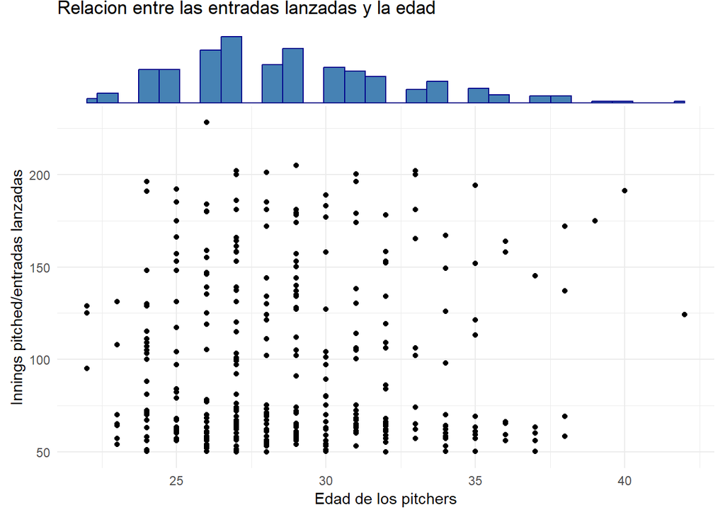

```r
grafica1 <- ggplot(mlb_players, aes(x = Age, y = IP, fill())) +
  geom_point() + labs(title = "Relacion entre las entradas lanzadas y la edad",  x = "Edad de los pitchers", y = "Innings pitched/entradas lanzadas") +
  theme_minimal()
ggMarginal(
  grafica1,
  type = "histogram",
  margins = "x",      # Especifica que solo se añada en el eje X (la Edad)
  fill = "steelblue",   # Color de relleno del histograma
  color = "darkblue"
)
```

Podemos visualizar que en el rango de edad donde se registraron mayor cantidad de inning/ entradas lanzadas fue entre los 25 a 30 años de edad, concentrandose con mayor frecuencia en un rango de entre 50 a 100 inning / entradas lanzadas.

## *Comparativa de las métricas de efectividad (ERA y WHIP) con respecto a edad*

### **Whip**

Mide la cantidad promedio de corredores que un lanzador permite que lleguen a base (ya sea por hit o por base por bolas) por cada entrada que lanza.

```r
best_whip <- mlb_players %>% arrange(WHIP, Age) %>% filter(WHIP < 1.5& Age > 20)
datatable(best_whip)
```

|  | Name | Age | IP | ERA | WHIP | FIP |
| --- | --- | --- | --- | --- | --- | --- |
| 1 | Emmanuel Clase | 24 | 72.2 | 1.36 | 0.729 | 1.98 |
| 2 | Ryan Helsley | 27 | 64.2 | 1.25 | 0.742 | 2.34 |
| 3 | Jacob deGrom | 34 | 64.1 | 3.08 | 0.746 | 2.13 |
| 4 | Jason Adam | 30 | 63.1 | 1.56 | 0.758 | 2.86 |
| 5 | Evan Phillips | 27 | 63 | 1.14 | 0.762 | 1.94 |
| 6 | Paul Sewald | 32 | 64 | 2.67 | 0.766 | 3.88 |
| 7 | Justin Verlander | 39 | 175 | 1.75 | 0.829 | 2.49 |
| 8 | Edwin Díaz | 28 | 62 | 1.31 | 0.839 | 0.9 |
| 9 | Tony Gonsolin | 28 | 130.1 | 2.14 | 0.875 | 3.28 |
| 10 | Eli Morgan | 26 | 66.2 | 3.38 | 0.885 | 3.58 |

[output cut: 299 more lines]

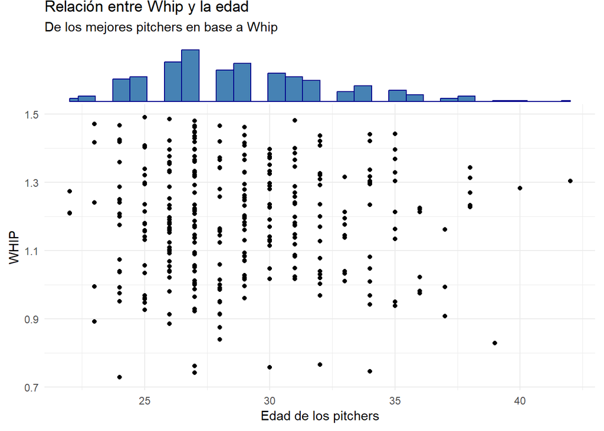

```r
grafica2 <- ggplot(best_whip, aes(x = Age, y = WHIP, fill())) +
  geom_point() + labs(title = "Relación entre Whip y la edad ", subtitle = "De los mejores pitchers en base a Whip",   x = "Edad de los pitchers", y = "WHIP") +
  theme_minimal()
ggMarginal(
  grafica2,
  type = "histogram",
  margins = "x",      # Especifica que solo se añada en el eje X (la Edad)
  fill = "steelblue",   # Color de relleno del histograma
  color = "darkblue")
```

Para filtrar los datos de forma que facilitaran el analisis de datos decidimos que aquellos jugadores condiderados como “mejores jugadores” se encuentran entre tener un Whip < 1.5 y mayores a una edad de 20 años.

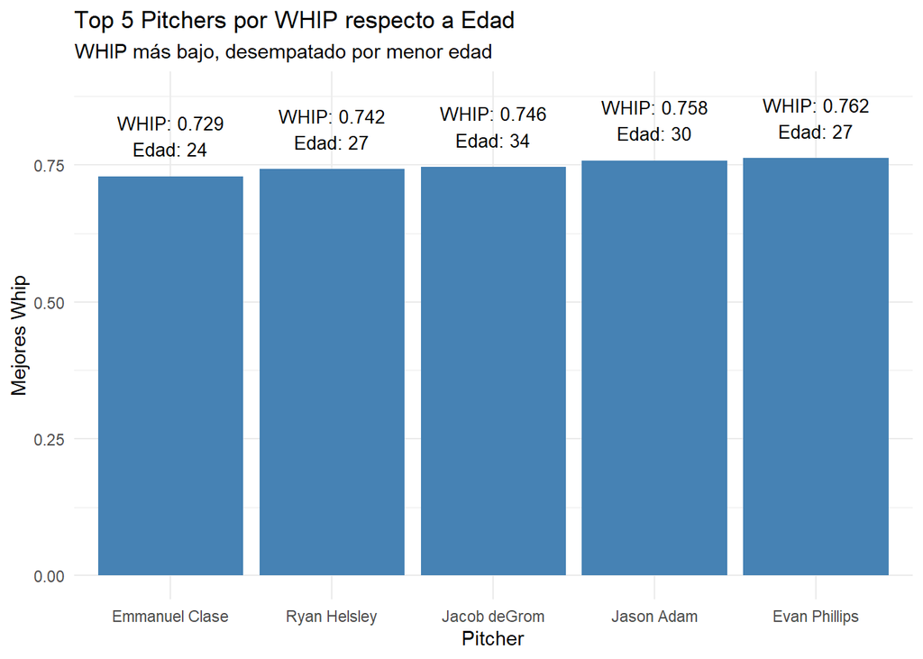

```r
top_5whip <- best_whip %>% arrange(WHIP, Age) %>% head(5)

ggplot(top_5whip, aes(x = reorder(Name, WHIP), y = WHIP)) +
  geom_col(fill = "steelblue") + geom_text(
    aes(label = paste0("WHIP: ", WHIP, "\nEdad: ", Age)),
    vjust = -0.5, # Ajusta la posición vertical (un poco arriba de la barra)
    size = 3.5
  ) + labs(
    title = "Top 5 Pitchers por WHIP respecto a Edad",
    subtitle = "WHIP más bajo, desempatado por menor edad",
    x = "Pitcher",
    y = "Mejores Whip"
  ) +

  # Un tema limpio
  theme_minimal() +

  # Opcional: Ajusta el límite del eje Y para dar espacio a las etiquetas
  ylim(0, max(top_5whip$WHIP) * 1.15)
```

sin embargo los resultados no suponen la existencia entre una correlación directa entre ambas variables (Whip y edad) para asegurarnos de esto vamos a visualizar al total de pitchers y evaluar su whip junto a su edad.

### **ERA**

Mide la cantidad promedio de carreras limpias (es decir, carreras que no fueron causadas por errores defensivos) que un lanzador permite por cada nueve entradas (un juego completo) que lanza.

```r
best_era<- mlb_players %>% arrange(ERA, Age) %>% filter(ERA < 4& Age > 20)
datatable(best_era)
```

|  | Name | Age | IP | ERA | WHIP | FIP |
| --- | --- | --- | --- | --- | --- | --- |
| 1 | Evan Phillips | 27 | 63 | 1.14 | 0.762 | 1.94 |
| 2 | Ryne Stanek | 30 | 54.2 | 1.15 | 1.226 | 3.02 |
| 3 | Ryan Helsley | 27 | 64.2 | 1.25 | 0.742 | 2.34 |
| 4 | Edwin Díaz | 28 | 62 | 1.31 | 0.839 | 0.9 |
| 5 | Emmanuel Clase | 24 | 72.2 | 1.36 | 0.729 | 1.98 |
| 6 | Cionel Pérez* | 26 | 57.2 | 1.4 | 1.162 | 2.8 |
| 7 | Anthony Bass | 34 | 70.1 | 1.54 | 1.009 | 3 |
| 8 | Jason Adam | 30 | 63.1 | 1.56 | 0.758 | 2.86 |
| 9 | Erik Swanson | 28 | 53.2 | 1.68 | 0.913 | 1.84 |
| 10 | Justin Verlander | 39 | 175 | 1.75 | 0.829 | 2.49 |

[output cut: 207 more lines]

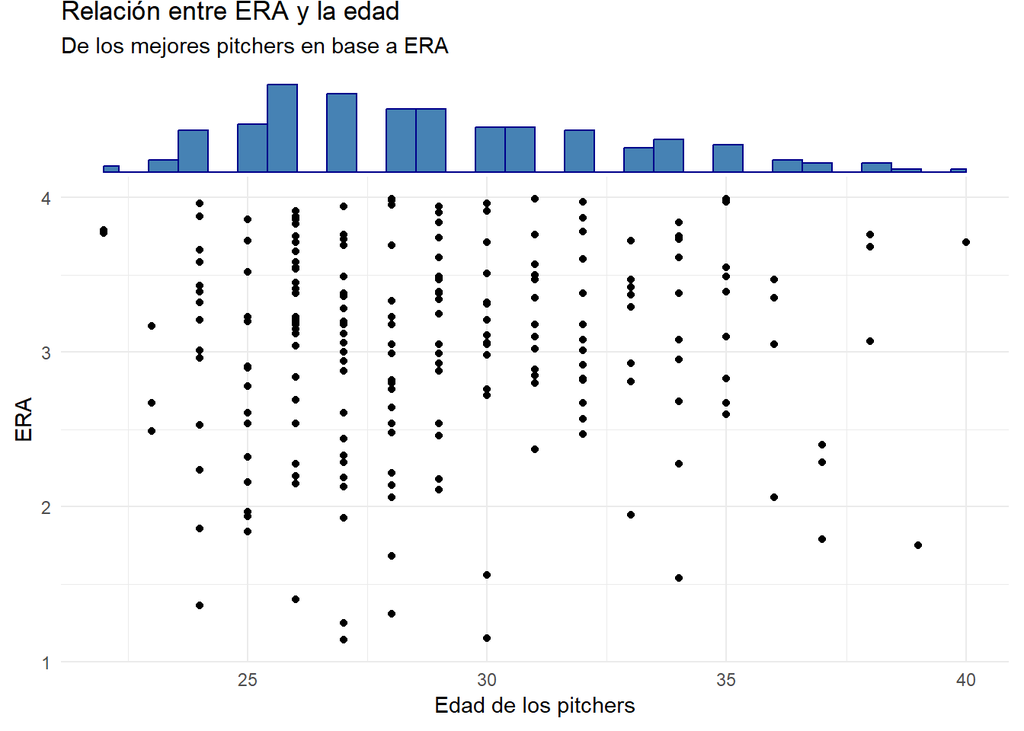

```r
grafica4 <- ggplot(best_era, aes(x = Age, y = ERA, fill())) +
  geom_point() + labs(title = "Relación entre ERA y la edad ", subtitle = "De los mejores pitchers en base a ERA",   x = "Edad de los pitchers", y = "ERA") +
  theme_minimal()
ggMarginal(
  grafica4,
  type = "histogram",
  margins = "x",      # Especifica que solo se añada en el eje X (la Edad)
  fill = "steelblue",   # Color de relleno del histograma
  color = "darkblue")
```

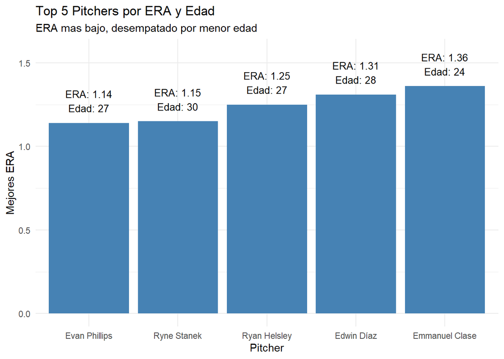

```r
top_5era <- best_era %>% arrange(ERA, Age) %>% head(5)

ggplot(top_5era, aes(x = reorder(Name, ERA), y = ERA)) +
  geom_col(fill = "steelblue") + geom_text(
    aes(label = paste0("ERA: ", ERA, "\nEdad: ", Age)),
    vjust = -0.5, # Ajusta la posición vertical (un poco arriba de la barra)
    size = 3.5
  ) + labs(
    title = "Top 5 Pitchers por ERA y Edad",
    subtitle = "ERA mas bajo, desempatado por menor edad",
    x = "Pitcher",
    y = "Mejores ERA"
  ) +

  # Un tema limpio
  theme_minimal() + ylim(0, max(top_5era$ERA) * 1.15)
```

```r
#se ajusta un limite para la altura de y
```

*Comparando ambas metricas de efectividad podemos notar que:*

-En ambas graficas la mayor concentración de pitchers de élite se encuentra en el rango de edad de 26 a 30 años, con un pico notable alrededor de los 26-28 años. Esto indica que la edad pico de rendimiento para los lanzadores más efectivos (ya sea por ERA o WHIP) se encuentra a finales de sus 20s.

-Los puntos de datos (rendimiento individual) están muy dispersos a lo largo del eje Y (la métrica). Esto sugiere que, dentro de este grupo ya selecto, no existe una correlación lineal fuerte y visible entre la edad y la efectividad. Un lanzador de 25 años puede tener un ERA o WHIP tan bueno o malo como uno de 35 años.

## *Relación entre la participación (IP) y la efectividad independiente en el “fildeo” (FIP)*

```r
ip_fip<- mlb_players %>% arrange(IP, FIP)
datatable(ip_fip)
```

|  | Name | Age | IP | ERA | WHIP | FIP |
| --- | --- | --- | --- | --- | --- | --- |
| 1 | Josh Hader* | 28 | 50 | 5.22 | 1.28 | 3.45 |
| 2 | Brett Martin* | 27 | 50 | 4.14 | 1.36 | 3.63 |
| 3 | Noé Ramirez | 32 | 50 | 5.22 | 1.42 | 5.15 |
| 4 | Joely Rodríguez* | 30 | 50.1 | 4.47 | 1.351 | 3.23 |
| 5 | Andrew Wantz | 26 | 50.1 | 3.22 | 1.152 | 4.48 |
| 6 | Ian Kennedy | 37 | 50.1 | 5.36 | 1.57 | 5.58 |
| 7 | Dylan Lee* | 27 | 50.2 | 2.13 | 0.987 | 2.66 |
| 8 | Richard Bleier* | 35 | 50.2 | 3.55 | 1.441 | 3.27 |
| 9 | Matt Brash | 24 | 50.2 | 4.44 | 1.559 | 3.51 |
| 10 | Hirokazu Sawamura | 34 | 50.2 | 3.73 | 1.421 | 4.16 |

[output cut: 337 more lines]

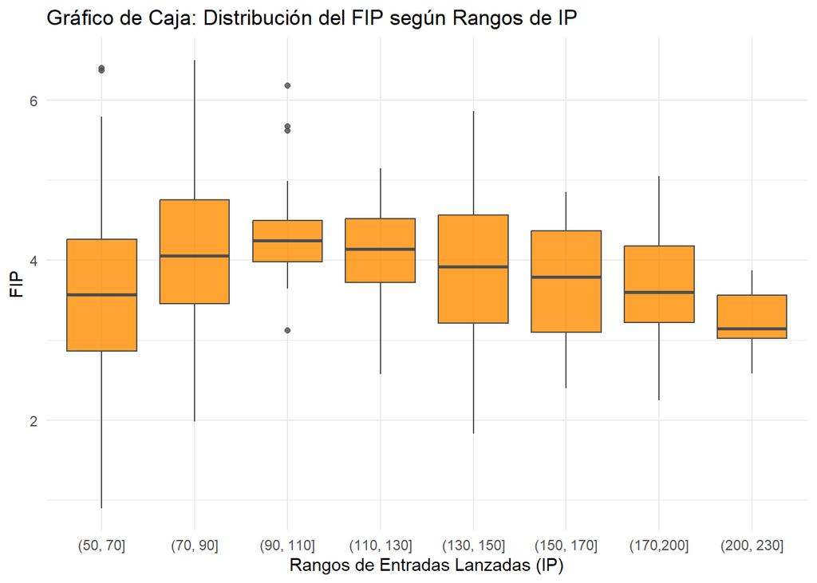

```r
ip_rang <- cut(ip_fip$IP, breaks = c(50, 70, 90, 110, 130, 150, 170,200,230), labels = c("(50, 70]", "(70, 90]", "(90, 110]","(110, 130]", "(130, 150]", "(150, 170]", "(170,200]", "(200, 230]"), include.lowest = TRUE, right = TRUE)

ggplot(ip_fip, aes(x = ip_rang, y = FIP)) + geom_boxplot(fill= "darkorange", color = "gray30", alpha = 0.8) + labs(title = "Gráfico de Caja: Distribución del FIP según Rangos de IP", x = "Rangos de Entradas Lanzadas (IP)", y = "FIP") + theme_minimal()
```

## *Pitchers con mejor ERA respecto a innings lanzados.*

```r
era_ip <- mlb_players %>% arrange(ERA, IP) %>% filter(ERA<4)

datatable(era_ip)
```

|  | Name | Age | IP | ERA | WHIP | FIP |
| --- | --- | --- | --- | --- | --- | --- |
| 1 | Evan Phillips | 27 | 63 | 1.14 | 0.762 | 1.94 |
| 2 | Ryne Stanek | 30 | 54.2 | 1.15 | 1.226 | 3.02 |
| 3 | Ryan Helsley | 27 | 64.2 | 1.25 | 0.742 | 2.34 |
| 4 | Edwin Díaz | 28 | 62 | 1.31 | 0.839 | 0.9 |
| 5 | Emmanuel Clase | 24 | 72.2 | 1.36 | 0.729 | 1.98 |
| 6 | Cionel Pérez* | 26 | 57.2 | 1.4 | 1.162 | 2.8 |
| 7 | Anthony Bass | 34 | 70.1 | 1.54 | 1.009 | 3 |
| 8 | Jason Adam | 30 | 63.1 | 1.56 | 0.758 | 2.86 |
| 9 | Erik Swanson | 28 | 53.2 | 1.68 | 0.913 | 1.84 |
| 10 | Justin Verlander | 39 | 175 | 1.75 | 0.829 | 2.49 |

[output cut: 207 more lines]

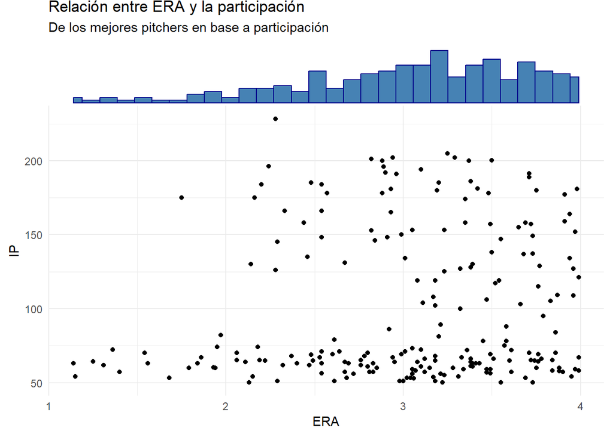

```r
graficeip <- ggplot(era_ip, aes(x = ERA, y = IP, fill())) +
  geom_point() + labs(title = "Relación entre ERA y la participación ", subtitle = "De los mejores pitchers en base a participación",   x = "ERA", y = "IP") +
  theme_minimal()
ggMarginal(
  graficeip,
  type = "histogram",
  margins = "x",      # Especifica que solo se añada en el eje X (la Edad)
  fill = "steelblue",   # Color de relleno del histograma
  color = "darkblue")
```